# A2 Python Analysis Project (Sayuri Tsunakawa)

## Introduction

Today, the bike rental market is experiencing an upward trend, due to increasing urbanization, growing health-consciousness, and evolving user preferences for flexible and sustainable transportation. Moreover, cycling is not just for leisure, it is also one of the major mean for commuting. This shifting trend sets the stage for understanding what factors drive or deter bike usages. Research shows that temporal, seasonal, and favorable weather-related factors significantly influence user behavior and usage patterns, while discomfort factors, such as heavy rain and high humidity, would likely suppress demand (ScienceDirect, Analytics Vidhya). Therefore, understanding these drivers that create high demand in fluctuating businesses like bike rentals are essential for maximizing sales and customer usage. Based on the insights and findings below, we can identify and deploy the most effective strategies to leverage our user engagement to stay competitive.

## Insights

1. The data shows that bicycles are likely used as a means of commuting. Based on the analysis of daily and weekly behavioral patterns of bike users, the highest demand for bike rentals is mainly on weekdays, especially from Monday to Thursday, during the rush hour between 6-7 PM. Friday evening was somewhat dispersed, with a higher demand starting from 4 PM, assuming some users would finish work early to enjoy their upcoming weekends. The second highest was morning at 8 AM, particularly on Wednesdays. Presumably, some users want to refresh and exercise on midweek mornings. These usage patterns confirm that bicycles are becoming a major mode of commuting, which drives peak demands for bike rentals.

2. The data shows that warmer temperature correlates with an increase in the rental counts. Among all the weather/comfort-related factors, temperature shows the strongest correlation with bike demands (0.55). For instance, June hits the highest average number of 1300+, with an average temperature between 20 to 25 ℃. However, the number of rentals drops during hotter seasons in July and August. This suggests that moderate and pleasant temperatures will encourage more people to cycle, which reinforces the necessity of seasonal strategies and campaigns.  
3. The data shows that adverse weather conditions deter rentals, only at high levels. Based on the results of rental counts with precipitation levels, indeed, a notable rise can be seen in no rainfall (0.0 mm) days. However, even within light rainfalls, between 1.0 to 2.5 mm, shows an upward trend in rentals. The downward trend can only be seen during heavy rainfalls of 3.0 mm and above. This indicates that lighter precipitation levels seem to be within an acceptable range for bike riders, and their direct impact may be partially offset when combined with other favorable conditions, such as temperature. (While humidity level is also another important indicator to consider, this study will mainly discuss rainfall as the key factor to describe "less favorable weather conditions" to support the following proposals for the company. Refer to appendix for further analysis for humidity if necessary.)

## Questions to consider

**1. Why are the majority of users renting bicycles?**

Through the analysis, the majority of users are renting bicycles for commuting. The data shows that bike rental demand peaks during weekday evening rush hours, particularly between 6-7 PM, followed by weekday morning, concentrated at 8 AM. This indicates a strong usage of bikes among daily urban commuters. The results can be reflected by users' lifestyle shifts and personal preferences, especially more choices for flexibility and a growing awareness of sustainability. In addition, rental volumes are also high during weekend afternoons, suggesting that leisure and recreational cycling contribute as well. Some users want to enjoy the last few hours before they get back to work or school, presumably returning home from social events and family gatherings or going out for dinner.

**2. What are ideal weather conditions that create high bike rental demand?**

Temperature and weather conditions play a key role. The demand increases accordingly with moderate temperatures. Overall, June had the highest average rental numbers, with an average temperature between 20 to 25 ℃. On the other hand, the number of rentals drops significantly in cold seasons or extremely hot days. Rainfall is another factor to consider. While seasons during heavy rains, average precipitation from 3.0 mm and above, reduce the demand significantly, lighter rainfalls have less impact and may partially offset when combined with other favorable conditions, such as warm weather. Therefore, the ideal weather conditions would be a mild to warm temperature, between 20 to 25 ℃, with light to no rainfall.

**3. Proposal for strategies and actionable steps**

1. To address the behavioral patterns of users, it is essential to explore ways to encourage more people to use bicycles for commuting. For instance, we see a strong demand for evening commutes, whereas morning usage is comparatively lower. Consider a bundle offer for round-trip users, such as "15 % discount for a return trip". This campaign will encourage people renting bicycles only for evening commuting to also consider morning rentals, ultimately lead to an increase in sales. Also, consider different pricing for different hours. For instance, set pricing for rush hours higher than usual daytime, since we observed a high demand during these hours.
2. To address leisure purposes, it is essential to explore ways to promote cycling as a valuable and engaging option to enhance quality time with friends and families. Consider a bundle offer for two or more riders, such as "Bring a friend and get 10% off each!". This share-ride campaign will attract new users and foster group participation, promoting social cycling experiences, which may eventually lead to repeat customers.
3. To address the weather condition, it is essential to explore ways to encourage more people to ride bicycles, especially in less favorable conditions, such as rainy days. Consider a "Double Points on Rainy day!" campaign, awarding double stamps on loyalty cards to help incentivize bike rentals and boost engagement despite the weather. Also, provide complimentary raincoat rentals to help reduce weather-related barriers and motivate users to continue cycling even in adverse conditions." By doing so, businesses can operate with greater confidence and stability, without the constant concern of weather forecasting and fluctuation in demand."

## Conclusion

Bike rentals are a fluctuating business, highly influenced by users' lifestyles and preferences, as well as external factors, such as weather. The analysis shows that rental demand peaks during evening commute hours, while morning usage remains an area of opportunity. Weekends also have the potential to generate more demand through appealing promotions and family-friendly offers. Furthermore, warmer temperatures encourage more ridership, while rainfalls may not necessarily discourage rental activities with the right strategies and campaigns in place, unless it is an extreme weather condition. By positioning cycling as a convenient, attractive, and reliable option for both commuting and leisure, it will become an integral part of everyday urban life. By capitalizing this trend and unlocking new growth opportunities, we can gain a competitive edge in the market and cultivate long-term customer loyalty.

## Reference

1. Meerah, K., Parin, C., Talha, A. (2024). A predictive analytics approach for forecasting bike rental demand. Decision Analytics Journal https://www.sciencedirect.com/science/article/pii/S2772662224000869
2. Saxena, A. (2023, May 21). End-to-end case study: Bike sharing demand prediction. Analytics Vidhya. https://www.analyticsvidhya.com/blog/2023/05/end-to-end-case-study-bike-sharing-demand-prediction/

```python
# importing packages
import pandas            as pd  # data science essentials
import matplotlib.pyplot as plt # NEW: data visualization essentials
import seaborn           as sns # NEW: enhanced data visualization

# suppressing user warnings
import warnings # warnings
warnings.simplefilter(action='ignore', category=UserWarning)


# storing the path to the dataset
file = 'bikes_data.xlsx'

# reading the file into Python through pandas
bikes = pd.read_excel(io       =  file,
                    sheet_name = 'SU (2 + 3)',
                     header     =  0)

# Display statistical analysis for numeric data
bikes.describe(include = "number").round(decimals = 2)
```

|  | ID | Hour | Temperature | Humidity | Wind Speed | Visibility | Dew Point Temperature | UV Index | Rainfall | Snowfall | RENTALS |
| --- | --- | --- | --- | --- | --- | --- | --- | --- | --- | --- | --- |
| count | 1387.00 | 1387.00 | 1387.00 | 1387.00 | 1387.00 | 1387.00 | 1387.00 | 1387.00 | 1387.00 | 1387.00 | 1387.00 |
| mean | 694.00 | 11.55 | 13.09 | 58.76 | 1.71 | 1434.42 | 4.37 | 0.57 | 0.14 | 0.08 | 810.02 |
| std | 400.54 | 6.92 | 11.90 | 20.56 | 1.02 | 618.09 | 13.10 | 0.87 | 1.26 | 0.44 | 694.72 |
| min | 1.00 | 0.00 | -15.80 | 11.00 | 0.00 | 81.00 | -30.50 | 0.00 | 0.00 | 0.00 | 5.00 |
| 25% | 347.50 | 6.00 | 3.20 | 43.00 | 0.90 | 946.00 | -4.40 | 0.00 | 0.00 | 0.00 | 250.50 |
| 50% | 694.00 | 12.00 | 14.10 | 58.00 | 1.50 | 1718.00 | 5.20 | 0.01 | 0.00 | 0.00 | 626.00 |
| 75% | 1040.50 | 18.00 | 22.80 | 75.00 | 2.30 | 2000.00 | 15.60 | 0.98 | 0.00 | 0.00 | 1196.50 |
| max | 1387.00 | 23.00 | 38.00 | 98.00 | 7.40 | 2000.00 | 26.60 | 3.45 | 35.00 | 7.00 | 3734.00 |

```python
# Display High Rentals (3000 and above)
highRentals = bikes[bikes.loc[ : , "RENTALS"] >= 3000 ]
highRentals.head(n=10)
```

|  | ID | Month | Day of Week | Hour | Temperature | Humidity | Wind Speed | Visibility | Dew Point Temperature | UV Index | Rainfall | Snowfall | Season | Holiday | RENTALS |
| --- | --- | --- | --- | --- | --- | --- | --- | --- | --- | --- | --- | --- | --- | --- | --- |
| 437 | 438 | Apr | Tuesday | 18 | 21.2 | 32 | 3.8 | 1927 | 3.8 | 0.94 | 0.0 | 0.0 | Spring | No | 3088 |
| 515 | 516 | May | Monday | 18 | 27.5 | 47 | 2.5 | 1113 | 15.1 | 0.43 | 0.0 | 0.0 | Spring | No | 3061 |
| 594 | 595 | June | Monday | 18 | 27.1 | 40 | 2.8 | 1811 | 12.3 | 1.00 | 0.0 | 0.0 | Summer | No | 3453 |
| 604 | 605 | June | Thursday | 18 | 26.2 | 54 | 2.2 | 1183 | 16.1 | 0.88 | 0.0 | 0.0 | Summer | No | 3640 |
| 605 | 606 | June | Thursday | 19 | 24.5 | 63 | 3.1 | 970 | 16.9 | 0.46 | 0.0 | 0.0 | Summer | No | 3021 |
| 641 | 642 | June | Thursday | 19 | 24.3 | 48 | 1.5 | 2000 | 12.5 | 0.59 | 0.0 | 0.0 | Summer | No | 3223 |
| 657 | 658 | June | Monday | 18 | 24.1 | 57 | 2.9 | 1301 | 15.0 | 0.56 | 0.0 | 0.0 | Summer | No | 3734 |
| 688 | 689 | June | Tuesday | 18 | 25.0 | 69 | 1.5 | 1125 | 18.9 | 0.52 | 0.0 | 0.0 | Summer | No | 3331 |
| 1055 | 1056 | Oct | Sunday | 18 | 16.6 | 61 | 2.9 | 2000 | 9.0 | 0.16 | 0.0 | 0.0 | Autumn | No | 3057 |

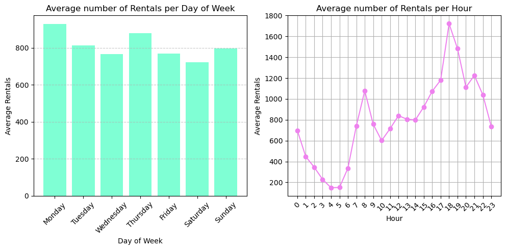

```python
# Displaying the average of number of RENTALS per Day of Week

# Define weekday order
weekday_order = ['Monday', 'Tuesday', 'Wednesday', 'Thursday', 'Friday', 'Saturday', 'Sunday']

bikes['Day of Week'] = pd.Categorical(bikes['Day of Week'],
                                      categories=weekday_order,
                                      ordered=True)

# Count how many times each Day of Week appears
Day_of_Week_counts = bikes['Day of Week'].value_counts()

# Sum RENTALS for each Day of Week
RENTALS_sums_d = bikes.groupby('Day of Week')['RENTALS'].sum()

# Calculate average manually: total RENTALS / count
average_RENTALS_d = (RENTALS_sums_d / Day_of_Week_counts).reindex(weekday_order)


##############Hour
# Displaying the average of number of RENTALS per Hour

# Count how many times each Hour appears
Hour_counts = bikes['Hour'].value_counts()

# Sum RENTALS for each month
RENTALS_sums_h = bikes.groupby('Hour')['RENTALS'].sum()

# Calculate average manually: total RENTALS / count
average_RENTALS_h = (RENTALS_sums_h / Hour_counts)



##############Visualize
# creating a bar chart　for Average number of Rentals per Day of Week(bar chart)
plt.figure(figsize = (15, 5))

plt.subplot(1, 3, 1)
plt.bar(average_RENTALS_d.index,
        average_RENTALS_d.values,
        color='aquamarine')
# Titles and labels
plt.title('Average number of Rentals per Day of Week')
plt.xlabel('Day of Week')
plt.ylabel('Average Rentals')
plt.xticks(rotation = 45)
plt.grid(axis = 'y',
         linestyle = '--',
         alpha = 0.7)


#creating a line chart　for Average number of Rentals per Hour(line chart)
plt.subplot(1, 3, 2)
plt.plot(average_RENTALS_h.index,
         average_RENTALS_h.values,
         marker='o',
         linestyle='-',
         color='violet')
# Titles and labels
plt.title('Average number of Rentals per Hour')
plt.xlabel('Hour')
plt.ylabel('Average Rentals')
plt.xticks(ticks = range(0, 24), rotation = 45)
plt.grid(True)

# visualizing the data
plt.tight_layout()
plt.show()
```

The two charts explain in more detail the rental demands and patterns by day of week and hour. The left shows that weekdays, especially Monday, followed by Thursday, have higher rentals, while Saturday drops to the lowest. The right shows that the highest peak is 18 PM and relatively spreads across evening hours, followed by another rise in demand at 8 AM. This further reveals the rental patterns with more evidence that bicycles are likely used and driven by commuting purposes, presumably for short-distance urban travels. Since the two charts do not fully explain the peak hour patterns by different days of week, refer to the heatmap below.

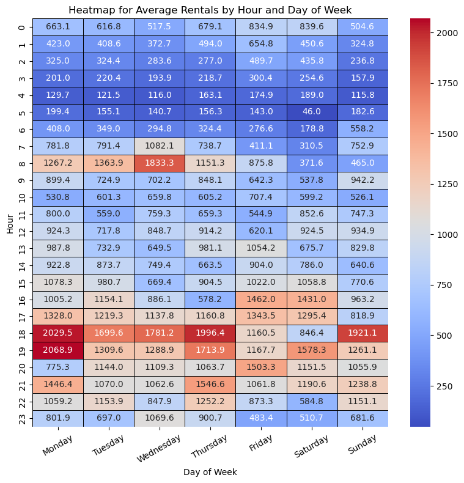

```python
# Average RENTALS for each Day of Week
RENTALS_sums_dayhour = bikes.groupby(['Day of Week', 'Hour'])['RENTALS'].sum()
rentals_count = bikes.groupby(['Day of Week', 'Hour'])['RENTALS'].count()
# Calculate average RENTALS
average_RENTALS_dayhour=(RENTALS_sums_dayhour / rentals_count).reset_index()
average_RENTALS_dayhour.columns = ['Day of Week', 'Hour', 'Average RENTALS']
average_RENTALS_dayhour['Day of Week'] = pd.Categorical(average_RENTALS_dayhour['Day of Week'],
                                             categories=weekday_order,
                                             ordered=True)

# Convert to pivot format (rows = hour, columns = day of the week, values = average number of rentals)
pivot_avg = average_RENTALS_dayhour.pivot(index='Hour',
                                          columns='Day of Week',
                                          values='Average RENTALS')
# developing a coolwarm heatmap
fig, ax = plt.subplots( figsize = (8 , 8) ) #specifying plot size
sns.heatmap(pivot_avg,
            cmap  = "coolwarm",
            annot = True,
            linecolor  = 'black', # lines between boxes
            linewidths = 0.5, # how thick should the lines be?
            fmt =".1f")

# title and displaying the plot
plt.title('Heatmap for Average Rentals by Hour and Day of Week')
plt.xlabel('Day of Week')
plt.ylabel('Hour')
plt.xticks(rotation = 30)
plt.tight_layout()
plt.show()
```

Above is a heatmap comparing the peaks for both "Day of Week" and "Hour", highlighting stronger rental patterns centered around the evening time, corresponding to evening commutes. A sharp rise can be seen especially during 6-7 PM from Sunday to Thursday, while Friday evening is relatively dispersed with higher demand from 4 PM, assuming some users would finish work early and want to enjoy Friday evening. Another high demand point is morning 8 AM from Monday to Thursday, corresponding to morning commutes, with Wednesday the highest. Presumably users want to refresh and exercise on midweeks morning. While weekend rentals are more dispersed around the evening, we can interpret that bike usages are for leisure-based rentals, to enjoy the last few hours before they get back to work or school, presumably returning home from social events and family gatherings or going out for dinner.

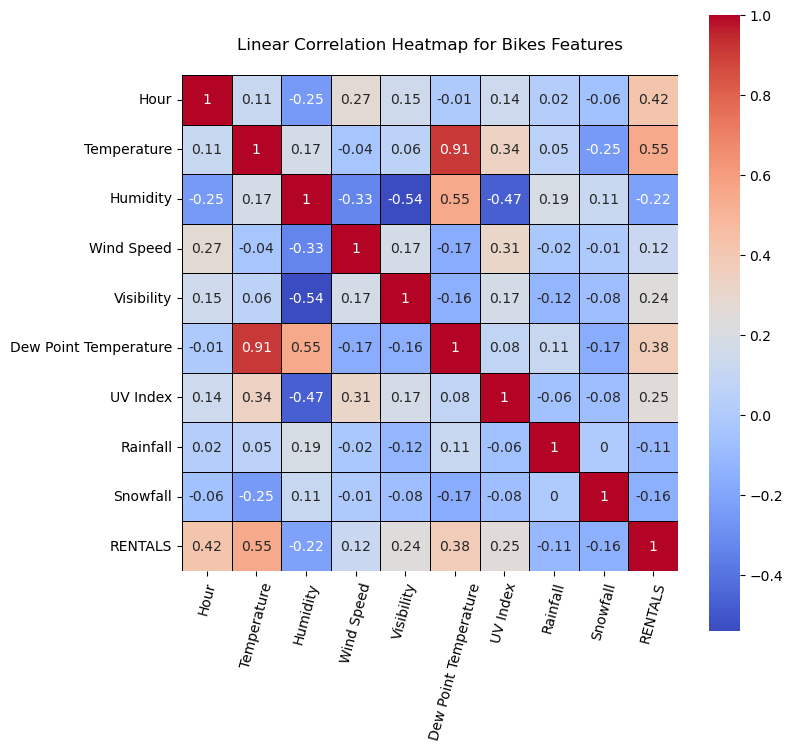

```python
# converting correlation matrix into a DataFrame
bikes_corr = bikes.iloc[ : , 1: ]. corr(method = 'pearson',
                                        numeric_only = True).round(decimals = 2)

# specifying plot size (making it bigger)
fig, ax = plt.subplots( figsize = (8 , 8) )


# developing a coolwarm heatmap
sns.heatmap(data       = bikes_corr, # the correlation matrix
            cmap       = "coolwarm", # changing to MEDIUM colors
            square     = True      , # tightening the layout
            annot      = True      , # should there be numbers in the heatmap
            linecolor  = 'black'   , # lines between boxes
            linewidths = 0.5       ) # how thick should the lines be?


# title and displaying the plot
plt.title(label = """
Linear Correlation Heatmap for Bikes Features
""")
plt.xticks(rotation = 75)

# visualizing the data
plt.show(block = True)
```

Next, above is a heatmap that shows the correlation between numerical factors, especially the factors that influence comfort level. The highest positive correlation is "Temperature" (0.55), indicating warmer temperatures encourage more users to rent bicycles. Hence, it is clear that temperature is one of the key factors that would influence user behavior and drive more demand. On the other hand, less favorable weather conditions such as "Humidity," "Rainfall," and "Snowfall" show negative correlations with the number of rentals, however, the impact appears to be relatively smaller than expected. This indicates that while these adverse factors may deter some users, they may not be the major standalone predictors.

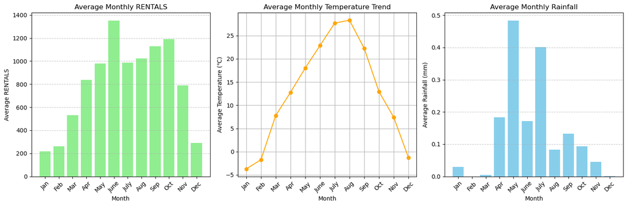

```python
# Displaying the average of rainfall per month

# Count how many times each month appears
month_counts = bikes['Month'].value_counts()

month_order = ["Jan", "Feb", "Mar", "Apr", "May", "June", "July", "Aug",\
               "Sep", "Oct", "Nov", "Dec"]
month_counts.index = pd.CategoricalIndex(month_counts.index,
                                         categories = month_order,
                                         ordered = True)
month_counts.sort_index()

# Sum rainfall for each month
rainfall_sums = bikes.groupby('Month')['Rainfall'].sum()

# Calculate average manually: total rainfall / count
average_rainfall = rainfall_sums / month_counts
average_rainfall= average_rainfall.reindex(month_order)


# Displaying the average of number of RENTALS per month

# Sum RENTALS for each month
RENTALS_sums = bikes.groupby('Month')['RENTALS'].sum()

# Calculate average manually: total RENTALS / count
average_RENTALS = RENTALS_sums / month_counts
average_RENTALS= average_RENTALS.reindex(month_order)


# Displaying the average Temperature per month

# Sum RENTALS for each month
Temperature_sums = bikes.groupby('Month')['Temperature'].sum()

# Calculate average manually: total Temperature / count
average_Temperature = Temperature_sums / month_counts
average_Temperature= average_Temperature.reindex(month_order)


# creating a bar chart for number of Rentals
plt.figure(figsize = (15, 5))

plt.subplot(1, 3, 1)
plt.bar(average_RENTALS.index,
        average_RENTALS.values,
        color = 'lightgreen')
# Titles and labels
plt.title('Average Monthly RENTALS')
plt.xlabel('Month')
plt.ylabel('Average RENTALS')
plt.xticks(rotation = 45)
plt.grid(axis = 'y',
         linestyle = '--',
         alpha = 0.7)

# creating a line chart for Temperature
plt.subplot(1, 3, 2)
plt.plot(average_Temperature.index,
         average_Temperature.values,
         marker='o',
         linestyle='-',
         color='orange')
plt.title('Average Monthly Temperature Trend')
plt.xlabel('Month')
plt.ylabel('Average Temperature (℃)')
plt.xticks(rotation=45)
plt.grid(True)

# creating a bar chart for Rainfall
plt.subplot(1, 3, 3)
plt.bar(average_rainfall.index, average_rainfall.values, color='skyblue')
# Titles and labels
plt.title('Average Monthly Rainfall')
plt.xlabel('Month')
plt.ylabel('Average Rainfall (mm)')
plt.xticks(rotation = 45)
plt.grid(axis = 'y',
         linestyle = '--',
         alpha = 0.7)

# visualizing the data
plt.tight_layout()
plt.show()
```

The above three charts show the average monthly trends for "RENTALS," "Rainfall," and "Temperature" to visually understand how the highest positive correlation factor (Temperature) and negative (Rainfall, as an example) discussed above affect user behaviors. The left and middle charts suggest that as the temperature gets warmer, the number of rentals increases accordingly, with a drop during the hottest season, from July and August. Shifting to the right chart, while May and July have dramatically higher rainfalls than other times of the year, it does not show a similar sharp decline in rentals. Therefore, although adverse weather conditions such as rainfall may influence user behaviors, their direct impact may be partially offset when combined with other favorable conditions. Moreover, even during the dry seasons, particularly August and winter, an extreme high or low temperature would likely stagnate the rental activities.

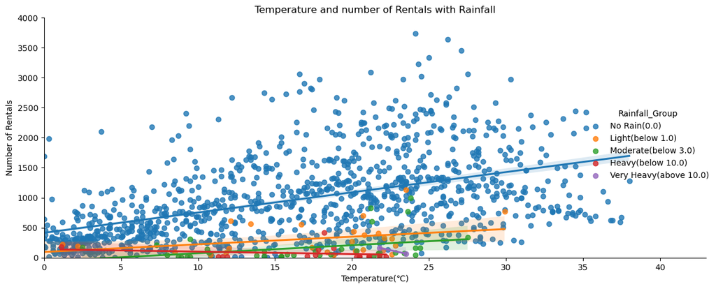

```python
# categorizing Rainfall
bikes['Rainfall_Group'] = pd.cut(bikes['Rainfall'],
                                  bins=[-0.1, 0.0, 0.9, 2.9, 9, 35],
                                  labels=['No Rain(0.0)', 'Light(below 1.0)',
                                          'Moderate(below 3.0)', 'Heavy(below 10.0)',
                                          'Very Heavy(above 10.0)'])

# instantiating a scatter plot for Temperature and number of Rentals
sns.lmplot(x          = 'Temperature' , # x-axis feature
           y          = 'RENTALS' , # y-axis feature
           hue        = "Rainfall_Group" , # categorical data for subsets
           scatter    = True    , # renders a scatter plot
           fit_reg    = True    , # renders a regression line
           aspect     = 2       , # aspect ratio for plot
           data       = bikes) # DataFrame where features exist


# formatting and displaying the plot
plt.title       (label  = 'Temperature and number of Rentals with Rainfall')
plt.xlabel      (xlabel = 'Temperature(℃)'          )
plt.ylabel      (ylabel = 'Number of Rentals'           )
plt.xlim        (left   = 0, right = 43.0          )
plt.ylim        (0, 4000)
plt.tight_layout(pad    = 1.0                     )
plt.show        (block  = True                    )
```

The scatter plot above shows the relationship between the number of "RENTALS" and "Temperature", with an additional parameter of "Rainfall" levels to visually compare each subset. This enables us to further understand the trend of how rental behavior changes under different precipitation levels. Overall, the "No Rain" shows a noticeable increase, followed by "Light" and "Moderate", although with some outliers, but still with an upward trend. On the other hand, the downward trend can be seen in "Heavy" and "Very Heavy" groups. This indicates that light to moderate levels (below 3.0 mm) of rainfall seem to be within an acceptable range for bike riders, whereas rental demand drops significantly when rainfall reaches a heavy point (above 3.0 mm). (For supplementary, refer to the appendix for a closer look of "Only Rainfall" trends, excluding "No Rainfall" data.)

**APPENDIX**

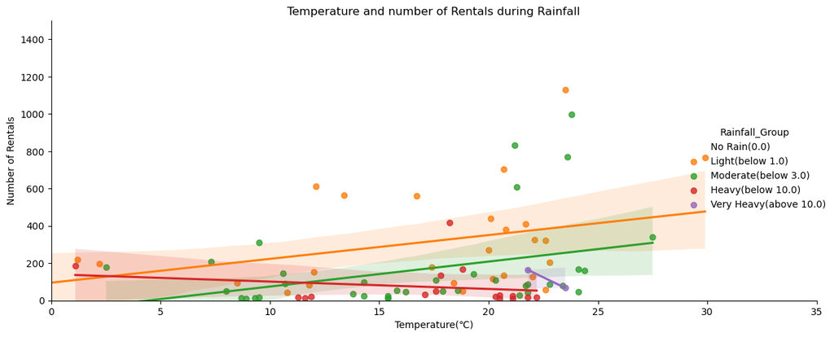

```python
rain_only = bikes[bikes['Rainfall'] > 0]

# categorizing Rainfall
bikes['Rainfall_Group'] = pd.cut(bikes['Rainfall'],
                                  bins=[-0.1, 0.0, 0.9, 2.9, 9, 35],
                                  labels=['No Rain(0.0)', 'Light(below 1.0)',
                                          'Moderate(below 3.0)', 'Heavy(below 10.0)',
                                          'Very Heavy(above 10.0)'])
# instantiating a scatter plot for Temperature and number of Rentals
sns.lmplot(x          = 'Temperature' , # x-axis feature
           y          = 'RENTALS' , # y-axis feature
           hue        = "Rainfall_Group" , # categorical data for subsets
           scatter    = True    , # renders a scatter plot
           fit_reg    = True    , # renders a regression line
           aspect     = 2       , # aspect ratio for plot
           data       = rain_only) # DataFrame where features exist


# formatting and displaying the plot
plt.title       (label  = 'Temperature and number of Rentals during Rainfall')
plt.xlabel      (xlabel = 'Temperature(℃)'          )
plt.ylabel      (ylabel = 'Number of Rentals'           )
plt.xlim        (left   = 0, right = 35.0          )
plt.ylim        (0, 1500)
plt.tight_layout(pad    = 1.0                     )
plt.show        (block  = True                    )
```

Above is a supplementary scatter plot excluding "No Rainfall" data, to have a closer look of the pattern of rental counts by rainfalls.

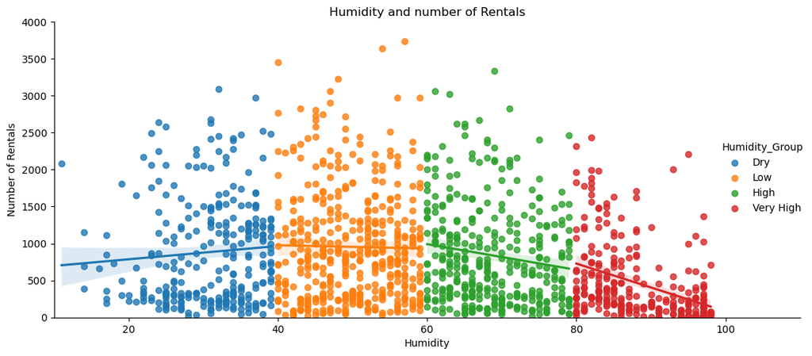

```python
# categorizing Humidity
bikes['Humidity_Group'] = pd.cut(bikes['Humidity'],
                                  bins=[10, 39, 59, 79, 100],
                                  labels=['Dry', 'Low', 'High', 'Very High'],
                                include_lowest=True)

# instantiating a scatter plot for Temperature and number of Rentals
sns.lmplot(x          = 'Humidity' , # x-axis feature
           y          = 'RENTALS' , # y-axis feature
           hue        = "Humidity_Group" , # categorical data for subsets
           scatter    = True    , # renders a scatter plot
           fit_reg    = True    , # renders a regression line
           aspect     = 2       , # aspect ratio for plot
           data       = bikes) # DataFrame where features exist

# formatting and displaying the plot
plt.title       (label  = 'Humidity and number of Rentals')
plt.xlabel      (xlabel = 'Humidity'          )
plt.ylabel      (ylabel = 'Number of Rentals'           )
plt.xlim        (left   = 10, right = 110.0          )
plt.ylim        (0, 4000)
plt.tight_layout(pad    = 1.0                     )
plt.show        (block  = True                    )
```

Above is another scatter plot that visualizes how humidity levels impact bike rental behavior. Divided into 4 categories, we see a downward trend in "High" level and above (above 60), indicating high humidity levels deter demand significantly. On the other hand, although "Light" level shows a flat trend, more rental counts seems to be clustered around this range. Refer to the box plot for more detailed view.

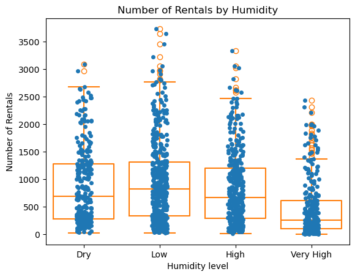

```python
# instatntiating a boxplot for Humidity and number of Rentals
sns.stripplot(x       = 'Humidity_Group' ,  # x-axis feature
              y       = 'RENTALS'        , # y-axis feature
             data     = bikes   ) # DataFrame where features exist

sns.boxplot(x         = 'Humidity_Group' ,
            y         = 'RENTALS'    ,
           data       = bikes   ,
           fill       = None)

# formatting and displaying the plot
plt.title  (label  = "Number of Rentals by Humidity")
plt.xlabel (xlabel = "Humidity level")
plt.ylabel (ylabel = "Number of Rentals")
plt.xticks(rotation=0)
plt.show   (block  = True   )
```

```python
month_order = ["Jan", "Feb", "Mar", "Apr", "May", "June", "July", "Aug",\
               "Sep", "Oct", "Nov", "Dec"]

#########top100

top100_rentals = bikes.sort_values(by='RENTALS', ascending=False).head(100)

# Sum rainfall for each month for Top 100
rainfall_sums_top100 = top100_rentals.groupby('Month')['Rainfall'].sum()

# Count how many times each month appears
month_counts_top100 = top100_rentals['Month'].value_counts()
month_counts_top100.index = pd.CategoricalIndex(month_counts_top100.index,
                                         categories = month_order,
                                         ordered = True)
month_counts_top100.sort_index()

# Calculate average manually: total rainfall / count
average_rainfall_top100 = rainfall_sums_top100 / month_counts_top100
average_rainfall_top100= average_rainfall_top100.reindex(month_order)

# Sum RENTALS for each month for Top 100
RENTALS_sums_top100 = top100_rentals.groupby('Month')['RENTALS'].sum()

# Calculate average manually: total RENTALS / count
average_RENTALS_top100 = RENTALS_sums_top100 / month_counts_top100
average_RENTALS_top100= average_RENTALS_top100.reindex(month_order)

# Sum RENTALS for each month for Top 100
Temperature_sums_top100 = top100_rentals.groupby('Month')['Temperature'].sum()

# Calculate average manually: total Temperature / count
average_Temperature_top100 = Temperature_sums_top100 / month_counts_top100
average_Temperature_top100= average_Temperature_top100.reindex(month_order)


######worst100
worst100_rentals = bikes.sort_values(by='RENTALS', ascending=True).head(100)

# Sum rainfall for each month for Top 100
rainfall_sums_worst100 = worst100_rentals.groupby('Month')['Rainfall'].sum()

# Count how many times each month appears
month_counts_worst100 = worst100_rentals['Month'].value_counts()
month_counts_worst100.index = pd.CategoricalIndex(month_counts_worst100.index,
                                         categories = month_order,
                                         ordered = True)
month_counts_worst100.sort_index()


# Sum rainfall for each month for Worst 100
rainfall_sums_worst100 = worst100_rentals.groupby('Month')['Rainfall'].sum()

# Calculate average manually: total rainfall / count
average_rainfall_worst100 = rainfall_sums_worst100 / month_counts_worst100
average_rainfall_worst100= average_rainfall_worst100.reindex(month_order)

# Sum RENTALS for each month for Worst 100
RENTALS_sums_worst100 = worst100_rentals.groupby('Month')['RENTALS'].sum()

# Calculate average manually: total RENTALS / count
average_RENTALS_worst100 = RENTALS_sums_worst100 / month_counts_worst100
average_RENTALS_worst100= average_RENTALS_worst100.reindex(month_order)

# Sum RENTALS for each month for Worst 100
Temperature_sums_worst100 = worst100_rentals.groupby('Month')['Temperature'].sum()

# Calculate average manually: total Temperature / count
average_Temperature_worst100 = Temperature_sums_worst100 / month_counts_worst100
average_Temperature_worst100= average_Temperature_worst100.reindex(month_order)
```

[figure not shown]

[figure not shown]

```python
# creating a visualization chart for Top 100
plt.figure(figsize = (15, 5))

# Average Monthly Rainfall for Top 100 (bar chart)
plt.subplot(1, 3, 1)
plt.bar(average_rainfall_top100.index,
        average_rainfall.values,
        color='skyblue')
# Titles and labels
plt.title('Average Monthly Rainfall for Top 100')
plt.xlabel('Month')
plt.ylabel('Average Rainfall (mm)')
plt.xticks(rotation = 45)
plt.grid(axis = 'y',
         linestyle = '--',
         alpha = 0.7)

# Average Monthly RENTALS for Top 100 (bar chart)
plt.subplot(1, 3, 2)
plt.bar(average_RENTALS_top100.index,
        average_RENTALS_top100.values,
        color = 'lightgreen')
# Titles and labels
plt.title('Average Monthly RENTALS for Top 100')
plt.xlabel('Month')
plt.ylabel('Average RENTALS')
plt.xticks(rotation = 45)
plt.grid(axis = 'y',
         linestyle = '--',
         alpha = 0.7)

# Average Monthly Temperature Trend (line chart)
plt.subplot(1, 3, 3)
plt.plot(average_Temperature_top100.index,
         average_Temperature_top100.values,
         marker='o',
         linestyle='-',
         color='orange')
# Titles and labels
plt.title('Average Monthly Temperature Trend for Top 100')
plt.xlabel('Month')
plt.ylabel('Average Temperature (℃)')
plt.xticks(rotation=45)
plt.grid(True)

# visualizing the data
plt.tight_layout()
plt.show()

######################
# creating a visualization chart for Worst 100
plt.figure(figsize = (15, 5))

# Average Monthly Rainfall for Worst 100 (bar chart)
plt.subplot(1, 3, 1)
plt.bar(average_rainfall_worst100.index,
        average_rainfall.values,
        color='skyblue')
# Titles and labels
plt.title('Average Monthly Rainfall for Worst 100')
plt.xlabel('Month')
plt.ylabel('Average Rainfall (mm)')
plt.xticks(rotation = 45)
plt.grid(axis = 'y',
         linestyle = '--',
         alpha = 0.7)

# Average Monthly RENTALS for Worst 100 (bar chart)
plt.subplot(1, 3, 2)
plt.bar(average_RENTALS_worst100.index,
        average_RENTALS_worst100.values,
        color = 'lightgreen')
# Titles and labels
plt.title('Average Monthly RENTALS for Worst 100')
plt.xlabel('Month')
plt.ylabel('Average RENTALS')
plt.xticks(rotation = 45)
plt.grid(axis = 'y',
         linestyle = '--',
         alpha = 0.7)

# Average Monthly Temperature Trend for Worst 100(line chart)
plt.subplot(1, 3, 3)
plt.plot(average_Temperature_worst100.index,
         average_Temperature_worst100.values,
         marker='o',
         linestyle='-',
         color='orange')
# Titles and labels
plt.title('Average Monthly Temperature Trend for Worst 100')
plt.xlabel('Month')
plt.ylabel('Average Temperature (℃)')
plt.xticks(rotation=45)
plt.grid(True)

# visualizing the data
plt.tight_layout()
plt.show()
```